# Lab 2 - Intro to Data - KEY

Total: 90 pts

## Lab report

**Load nycflights data**

```r
load(url("https://stat.duke.edu/~mc301/data/nycflights.RData"))
```

#### Exercises (45 pts)

#### Exercise 1:

```
8 pts:
4 pts - include correct code (already given in lab)
4 pts - reasonable answer about comparing the histograms
```

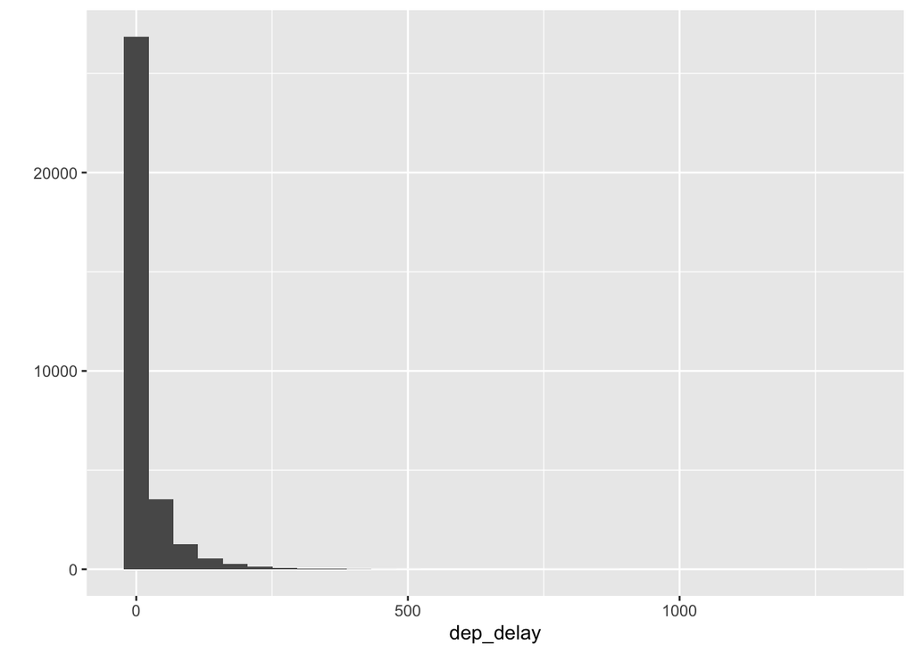

```r
qplot(x = dep_delay, data = nycflights, geom = "histogram")
```

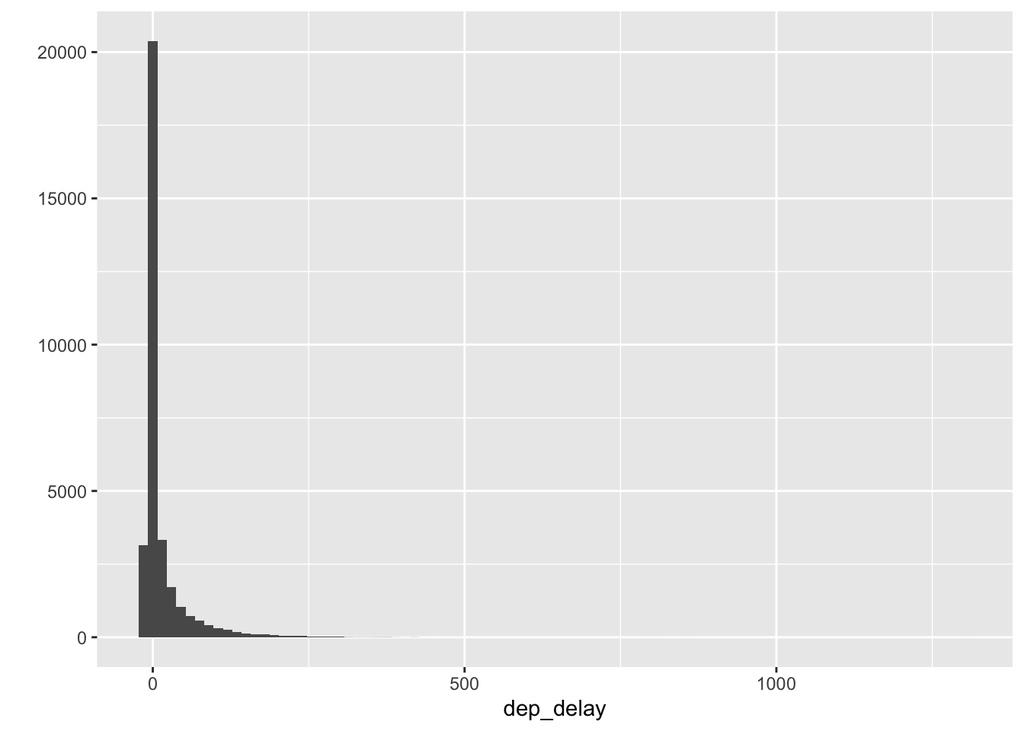

```r
qplot(x = dep_delay, data = nycflights, geom = "histogram", binwidth = 15)
```

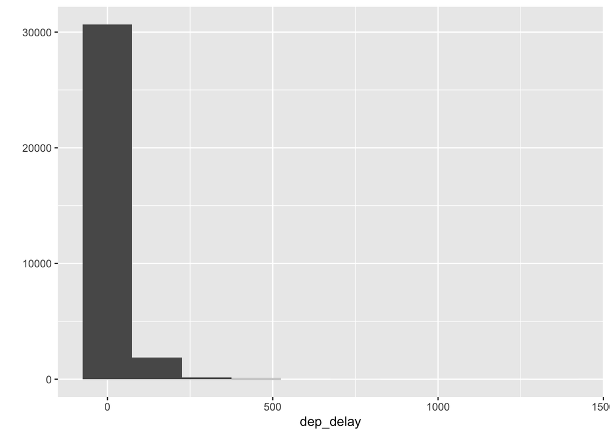

```r
qplot(x = dep_delay, data = nycflights, geom = "histogram", binwidth = 150)
```

#### Exercise 2:

```
6 pts
3 pts - Code
3 pts - Answer
```

68 flights meet the criteria

```r
sfo_feb_flights <- filter(nycflights, dest == "SFO", month == 2)
nrow(sfo_feb_flights)
```

```
## [1] 68
```

#### Exercise 3:

```
11 pts:
5 pts - Code (2pt for the histogram, 3pt for the data summary)
3 pts - Description
3 pts - Summary stats matches description
```

- The distribution is unimodal and slightly right skewed. It appears to be centered near 0 with several extreme values on the right side.
- Because of the presence of skew, we should use median/IQR

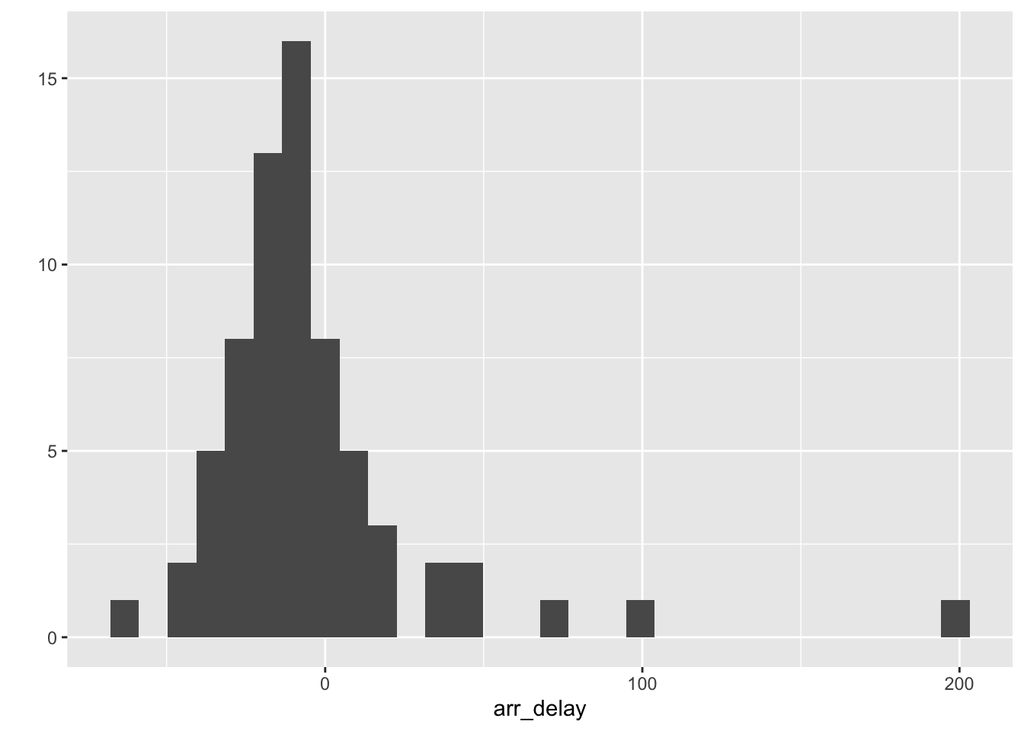

```r
qplot(x = arr_delay, data = sfo_feb_flights, geom = "histogram")
```

```r
sfo_feb_flights %>%
  summarise(med = median(arr_delay), iqr = IQR(arr_delay),
            min = min(arr_delay), max = max(arr_delay))
```

```
## # A tibble: 1 x 4
##     med   iqr   min   max
##   <dbl> <dbl> <dbl> <dbl>
## 1   -11  23.2   -66   196
```

#### Exercise 4:

```
6 pts
4 pts - Code
2 pt - Choosing DL (Delta) & UA (United Airlines)
```

DA (Delta) and UA (United) have the same, and highest, variability.

```r
sfo_feb_flights %>%
  group_by(carrier) %>%
  summarise(med_adel = median(arr_delay), IQR_adel = IQR(arr_delay), n = n()) %>%
  arrange(IQR_adel)
```

```
## # A tibble: 5 x 4
##   carrier med_adel IQR_adel     n
##   <chr>      <dbl>    <dbl> <int>
## 1 B6         -10.5     12.2     6
## 2 AA           5       17.5    10
## 3 VX         -22.5     21.2    12
## 4 DL         -15       22      19
## 5 UA         -10       22      21
```

#### Exercise 5:

```
9 pts
4 pts - Choosing the right months (2pt for July, 2pt for December)
5 pts - Choosing the right measure
```

July has the largest mean delay out of all the months at 20.75 minutes. December has the largest median delay at 1 minute.

Median would be more reliable as we already saw that delays were right skewed.

```r
nycflights %>%
  group_by(month) %>%
  summarise(mean_ddel = mean(dep_delay)) %>%
  arrange(desc(mean_ddel))
```

```
## # A tibble: 12 x 2
##    month mean_ddel
##    <int>     <dbl>
##  1     7     20.8
##  2     6     20.4
##  3    12     17.4
##  4     4     14.6
##  5     3     13.5
##  6     5     13.3
##  7     8     12.6
##  8     2     10.7
##  9     1     10.2
## 10     9      6.87
## 11    11      6.10
## 12    10      5.88
```

```r
nycflights %>%
    group_by(month) %>%
    summarise(median_dd = median(dep_delay)) %>%
    arrange(desc(median_dd))
```

```
## # A tibble: 12 x 2
##    month median_dd
##    <int>     <dbl>
##  1    12         1
##  2     6         0
##  3     7         0
##  4     3        -1
##  5     5        -1
##  6     8        -1
##  7     1        -2
##  8     2        -2
##  9     4        -2
## 10    11        -2
## 11     9        -3
## 12    10        -3
```

#### Exercise 6:

```
5 pts - Choosing LGA
(code given)
```

Choose LGA.

```r
nycflights <- nycflights %>%
  mutate(dep_type = ifelse(dep_delay < 5, "on time", "delayed"))

nycflights %>%
  group_by(origin) %>%
  summarise(ot_dep_rate = sum(dep_type == "on time") / n()) %>%
  arrange(desc(ot_dep_rate))
```

```
## # A tibble: 3 x 2
##   origin ot_dep_rate
##   <chr>        <dbl>
## 1 LGA          0.728
## 2 JFK          0.694
## 3 EWR          0.637
```

### More practice: (45 pts)

#### 7:

```
6 pts - Code
(no narrative needed)
```

```r
nycflights <- nycflights %>%
  mutate(avg_speed = distance / (air_time / 60))
```

#### 8:

```
17 pts:
6 pts - Code
6 pts - Relationship
5 pts - Mentioning the gap in distances
```

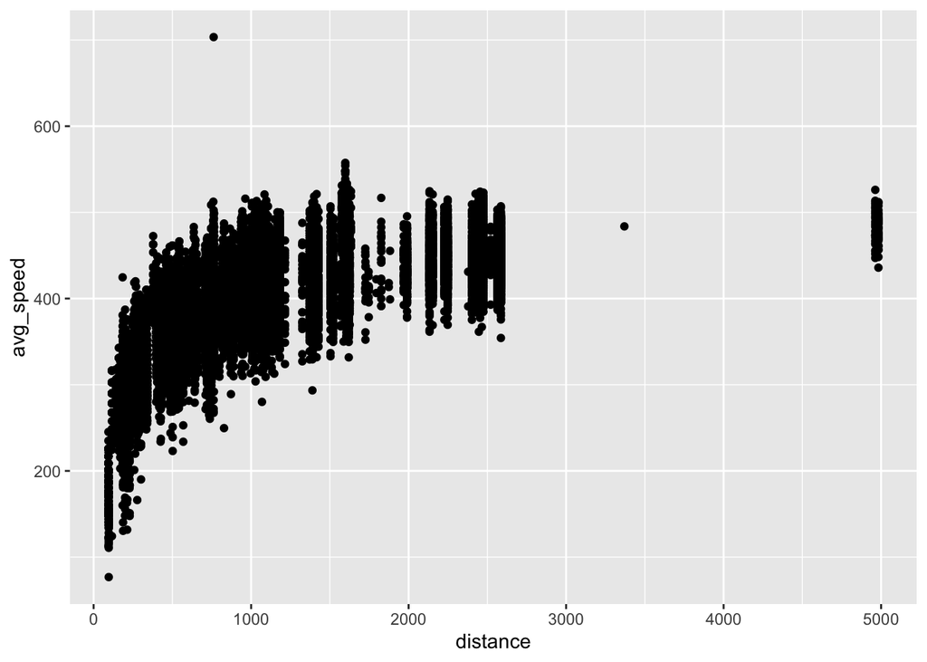

```r
qplot(y = avg_speed, x = distance, data = nycflights, geom = "point")
```

#### 9:

```
12 pts:
8 pts - code
4 pts - answer in text
```

18.33% of flights that depart late arrive on time.

```r
nycflights %>%
  mutate(arr_type = ifelse(arr_delay <= 0, "on time", "delayed")) %>%
  group_by(dep_type) %>%
  summarise(on_time_perc = sum(arr_type == "on time") / n())
```

```
## # A tibble: 2 x 2
##   dep_type on_time_perc
##   <chr>           <dbl>
## 1 delayed         0.183
## 2 on time         0.776
```

```r
head(nycflights)
```

```
##   year month day dep_time dep_delay arr_time arr_delay carrier tailnum
## 1 2013     6  30      940        15     1216        -4      VX  N626VA
## 2 2013     5   7     1657        -3     2104        10      DL  N3760C
## 3 2013    12   8      859        -1     1238        11      DL  N712TW
## 4 2013     5  14     1841        -4     2122       -34      DL  N914DL
## 5 2013     7  21     1102        -3     1230        -8      9E  N823AY
## 6 2013     1   1     1817        -3     2008         3      AA  N3AXAA
##   flight origin dest air_time distance hour minute dep_type avg_speed
## 1    407    JFK  LAX      313     2475    9     40  delayed  474.4409
## 2    329    JFK  SJU      216     1598   16     57  on time  443.8889
## 3    422    JFK  LAX      376     2475    8     59  on time  394.9468
## 4   2391    JFK  TPA      135     1005   18     41  on time  446.6667
## 5   3652    LGA  ORF       50      296   11      2  on time  355.2000
## 6    353    LGA  ORD      138      733   18     17  on time  318.6957
```

#### 10:

```
10 pts:
5 pts - Code
5 pts - Reasonable answer on the cutoff
```

It seems that if you are delayed by less than 25 minutes for departure, you can still reasonably expect to get to your destination on time. If you are delayed by at least 50 minutes for departure, you essentially have no chance at arriving on time.

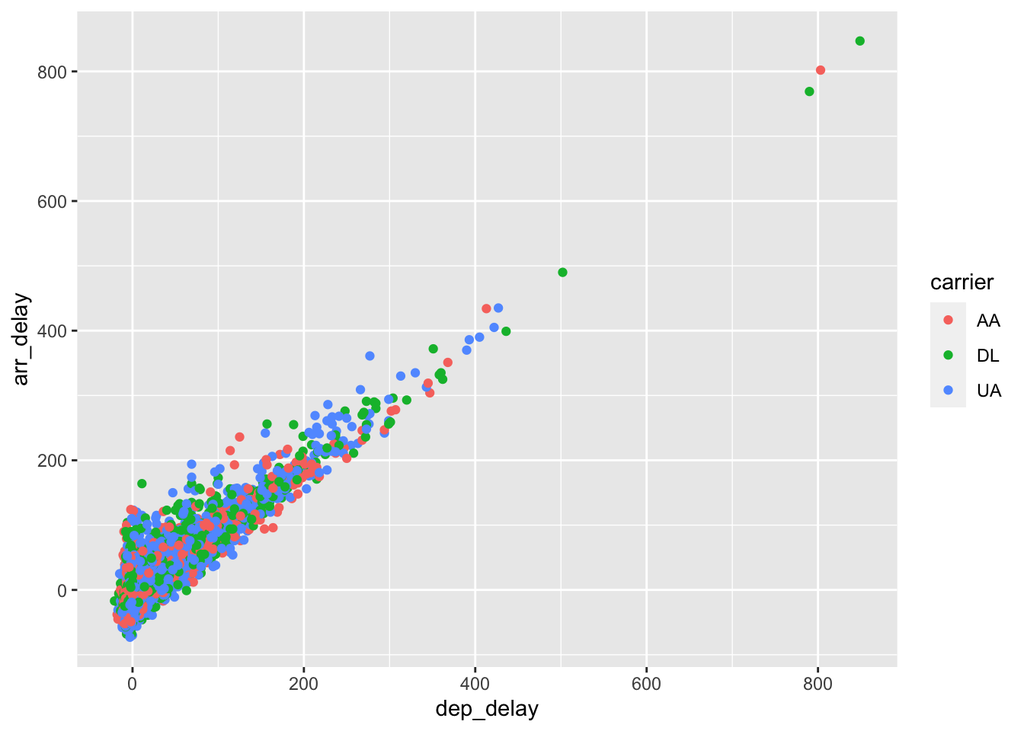

```r
dl_aa_ua <- nycflights %>%
  filter(carrier == "AA" | carrier == "DL" | carrier == "UA")
qplot(x = dep_delay, y = arr_delay, data = dl_aa_ua, color = carrier)
```